# 原子半径与元素周期律

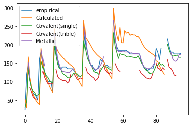

## 什么是原子半径——原子半径是如何计算的？

### 实验测量

#### Metallic Radii

[figure not shown]

- 当我们沿着元素周期表的一列向下移动时，金属半径会变大

  > 价电子位于较大的轨道中。
- 当我们从左到右穿过元素周期表的一行时，金属半径变小

  > 当我们穿过表格的一行时，原子核中的质子数量也会增加。 原子核倾向于将电子更紧密地保持在同一轨道壳层中，原子变得更小。

#### Covalent Radii

> 化合半径通常要比金属半径小 **eg**

[figure not shown]

#### Ionic Radii

> 通过分析离子晶体结构获得离子半径相对大小

[figure not shown]

##### 实验结果

> [Slater, J. C. (1964). "Atomic Radii in Crystals". Journal of Chemical Physics. 41 (10): 3199–3205. Bibcode:1964JChPh..41.3199S. doi:10.1063/1.1725697]

| **Group** (column) | **1** | **2** |  | **3** | **4** | **5** | **6** | **7** | **8** | **9** | **10** | **11** | **12** | **13** | **14** | **15** | **16** | **17** | **18** |  |  |
| --- | --- | --- | --- | --- | --- | --- | --- | --- | --- | --- | --- | --- | --- | --- | --- | --- | --- | --- | --- | --- | --- |
| **Period** (row) |  |  |  |  |  |  |  |  |  |  |  |  |  |  |  |  |  |  |  |  |  |
| **1** | H 25 |  |  |  |  |  |  |  |  |  |  |  |  |  |  |  |  |  | He |  |  |
| **2** | Li 145 | Be 105 |  |  |  |  |  |  |  |  |  |  |  | B 85 | C 70 | N 65 | O 60 | F 50 | Ne |  |  |
| **3** | Na 180 | Mg 150 |  |  |  |  |  |  |  |  |  |  |  | Al 125 | Si 110 | P 100 | S 100 | Cl 100 | Ar |  |  |
| **4** | K 220 | Ca 180 |  | Sc 160 | Ti 140 | V 135 | Cr 140 | Mn 140 | Fe 140 | Co 135 | Ni 135 | Cu 135 | Zn 135 | Ga 130 | Ge 125 | As 115 | Se 115 | Br 115 | Kr |  |  |
| **5** | Rb 235 | Sr 200 |  | Y 180 | Zr 155 | Nb 145 | Mo 145 | Tc 135 | Ru 130 | Rh 135 | Pd 140 | Ag 160 | Cd 155 | In 155 | Sn 145 | Sb 145 | Te 140 | I 140 | Xe |  |  |
| **6** | Cs 260 | Ba 215 | * | Lu 175 | Hf 155 | Ta 145 | W 135 | Re 135 | Os 130 | Ir 135 | Pt 135 | Au 135 | Hg 150 | Tl 190 | Pb 180 | Bi 160 | Po 190 | At | Rn |  |  |
| **7** | Fr | Ra 215 | ** | Lr | Rf | Db | Sg | Bh | Hs | Mt | Ds | Rg | Cn | Nh | Fl | Mc | Lv | Ts | Og |  |  |
|  |  |  | * | La 195 | Ce 185 | Pr 185 | Nd 185 | Pm 185 | Sm 185 | Eu 185 | Gd 180 | Tb 175 | Dy 175 | Ho 175 | Er 175 | Tm 175 | Yb 175 |  |  |  |  |
|  |  |  | ** | Ac 195 | Th 180 | Pa 180 | U 175 | Np 175 | Pu 175 | Am 175 | Cm | Bk | Cf | Es | Fm | Md | No |  |  |  |  |

### 理论计算，基于量子力学模型

> Clementi, E.; Raimond, D. L.; Reinhardt, W. P. (1967). "Atomic Screening Constants from SCF Functions. II. Atoms with 37 to 86 Electrons". Journal of Chemical Physics. 47 (4): 1300–1307. Bibcode:1967JChPh..47.1300C. doi:10.1063/1.1712084

| **Group** (column) | **1** | **2** |  | **3** | **4** | **5** | **6** | **7** | **8** | **9** | **10** | **11** | **12** | **13** | **14** | **15** | **16** | **17** | **18** |  |
| --- | --- | --- | --- | --- | --- | --- | --- | --- | --- | --- | --- | --- | --- | --- | --- | --- | --- | --- | --- | --- |
| **Period** (row) |  |  |  |  |  |  |  |  |  |  |  |  |  |  |  |  |  |  |  |  |
| **1** | H 53 |  |  |  |  |  |  |  |  |  |  |  |  |  |  |  |  |  | He 31 |  |
| **2** | Li 167 | Be 112 |  |  |  |  |  |  |  |  |  |  |  | B 87 | C 67 | N 56 | O 48 | F 42 | Ne 38 |  |
| **3** | Na 190 | Mg 145 |  |  |  |  |  |  |  |  |  |  |  | Al 118 | Si 111 | P 98 | S 88 | Cl 79 | Ar 71 |  |
| **4** | K 243 | Ca 194 |  | Sc 184 | Ti 176 | V 171 | Cr 166 | Mn 161 | Fe 156 | Co 152 | Ni 149 | Cu 145 | Zn 142 | Ga 136 | Ge 125 | As 114 | Se 103 | Br 94 | Kr 88 |  |
| **5** | Rb 265 | Sr 219 |  | Y 212 | Zr 206 | Nb 198 | Mo 190 | Tc 183 | Ru 178 | Rh 173 | Pd 169 | Ag 165 | Cd 161 | In 156 | Sn 145 | Sb 133 | Te 123 | I 115 | Xe 108 |  |
| **6** | Cs 298 | Ba 253 | * | Lu 217 | Hf 208 | Ta 200 | W 193 | Re 188 | Os 185 | Ir 180 | Pt 177 | Au 174 | Hg 171 | Tl 156 | Pb 154 | Bi 143 | Po 135 | At 127 | Rn 120 |  |
| **7** | Fr | Ra | ** | Lr | Rf | Db | Sg | Bh | Hs | Mt | Ds | Rg | Cn | Nh | Fl | Mc | Lv | Ts | Og |  |
|  |  |  | * | La 226 | Ce 210 | Pr 247 | Nd 206 | Pm 205 | Sm 238 | Eu 231 | Gd 233 | Tb 225 | Dy 228 | Ho 226 | Er 226 | Tm 222 | Yb 222 |  |  |  |
|  |  |  | ** | Ac | Th | Pa | U | Np | Pu | Am | Cm | Bk | Cf | Es | Fm | Md | No |  |  |  |

## QUES.

> - 原子半径相对变化（最大/最小 500%），而电子数变化为180，那么电子平均密度（想象原子为3维空间球体）增加了1.44倍，随电子数增加，电子反而靠的更紧了？
> - 原子半径由哪些因素决定？

## 原子半径与Bohr theorem

### 碱金属原子

### 仅考虑核电荷数——行星原子模型

n表示周期数，对最外层电子 $$E_n = -\frac{Ze^2}{8\pi\epsilon_0R_n}$$ 那么原子半径与能量（绝对值）的乘积应该与Z成正比

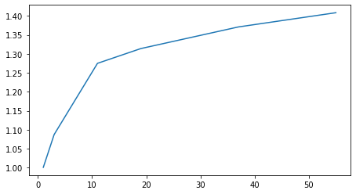

### 考虑屏蔽系数和能级——波尔理论

在波尔的原子模型中，对电子轨道做了定态假设，同时，Moseley 在用玻尔理论解释X射线特征谱时用到了屏蔽系数\ 如果我们在计算基态能量时将这两方面因素都考虑进去则有 $$E_n = -\frac{m_0c^2}{2}(\frac{Z^*\alpha}{n})^2$$ 其中$E_n$表示电子在能层n的基态能量，$Z^*$表示有效电荷数，e表示电子电荷,$\alpha$为精细结构常数$m_0c^2$为电子静止质量\ 那么同时考虑两方面因素，原子半径可以按如下公式计算 $$R_n = \frac{n^2}{Z^*}a_1$$ 其中$R_n$表示能层n的半径，$Z^*$表示有效电荷数，e表示电子电荷,$a_1$为第一波尔半径

$$R_n=[0.53,1.52,1.86,2.31,2.44,2.62]$$$$R_n/R_1 = \frac{n^2}{Z^*}$$

$$E_n=[13.6,5.4,5.1,4.3,4.2,3.9]$$$$E_n/E_1 = \frac{{Z^*}^2}{n^2}$$

# 同周期原子半径变化

由于质子数量的增加，原子半径在整个周期内减小。 因此，质子和电子之间的吸引力更大，因为相反的电荷相吸，质子越多，电荷越强。 吸引力越大，电子就越靠近质子，从而减小粒子的尺寸。

## 将原子实模型用到外层多电子体系

我们知道波尔的原子模型的一个局限性就是它不适用于外层多电子原子体系，但如果换一种角度看，我们把原子内层看作原子实，引入屏蔽系数衡量内层电子对原子核的屏蔽作用，那么是不是也可以把最高能级的电子以内看作原子实来衡量其内部电子对原子核的屏蔽作用呢？ 在这个模型中，原子最高能级的电子其基态能量与半径可表示如下：$$E = -\frac{Z^*e^2}{8\pi\epsilon_0R}$$ 其中E表示电子经典基态能量，$Z^*$表示有效电荷数，e表示电子电荷，R为原子半径\

事实上，我们关心的是内部电子对原子核的屏蔽作用，即单位原子核电荷数在屏蔽效应下被削弱的电荷数，我们可以这样表示 $$\sigma = 1-\frac{Z^*}{Z}$$ 其中$Z^*$是上式计算的有效电荷数，$Z$是原子的核电荷数。 下面我们以第二三周期元素为例，来说明这个计算公式的有效性。

## 以第二周期主族元素为例

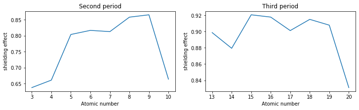

# 结论

基于上述分析，我们得到影响原子半径的因素如下

| 因素 | 规则 | 表示 | *趋势* | 原子半径影响 |
| --- | --- | --- | --- | --- |
| 电子壳层 | 量子力学 | 主量子数和角量子数 | 按列增加 | 增大原子半径 |
| 核电荷数 | 原子核中的质子对电子产生的吸引力 | 原子序数 | 同周期增加（从左到右） | 减小原子半径 |
| 屏蔽效应（贯穿效应 | 内部电子对最外层电子的排斥力 | 内壳中的电子数 | 减少核电荷数的影响 | 增加原子半径 |